# PROJET

Relation entre les variables :

La mortalité de la tuberculose (toutes formes, excluant VIH) dans la population générale est positivement liée à la mortalité de la tuberculose chez les personnes vivant avec le VIH.

Pour chaque augmentation de 1 décès par 100 000 habitants dans la mortalité des personnes vivant avec le VIH, la mortalité de la tuberculose (excluant le VIH) augmente de 0.34 décès par 100 000 habitants.

Significativité :

Le p-value de la variable indépendante (mortalité chez les personnes vivant avec le VIH) est très faible (< 2e-16), ce qui signifie que cette relation est hautement significative.

L’intercept (constante) est également significatif avec un p-value de 1.55e-13.

R-squared :

Le modèle explique 29.4% de la variance dans la mortalité de la tuberculose (excluant le VIH). Cela suggère que d’autres facteurs non inclus dans ce modèle peuvent aussi influencer la mortalité de la tuberculose.

Le F-statistic est élevé (87.45), ce qui montre que le modèle est globalement significatif et que la relation entre les deux variables est robuste.

Ainsi, le modèle montre que la mortalité chez les personnes vivant avec le VIH est un prédicteur significatif de la mortalité de la tuberculose dans la population générale, bien que le modèle n’explique qu’environ 29.4% de la variance.

##résidus versus valeurs ajustées

`r ggplot() + aes(x = fitted(mortality_vs_hiv), y = residuals(mortality_vs_hiv)) + geom_point() + geom_smooth() + xlab("Valeurs ajustées") + ylab("Résidus du modèle") + ggtitle("Résidus en fonction des valeurs ajustées", subtitle = "Moratlité avec / sans VIH")`

`` ## `geom_smooth()` using method = 'loess' and formula = 'y ~ x' ``

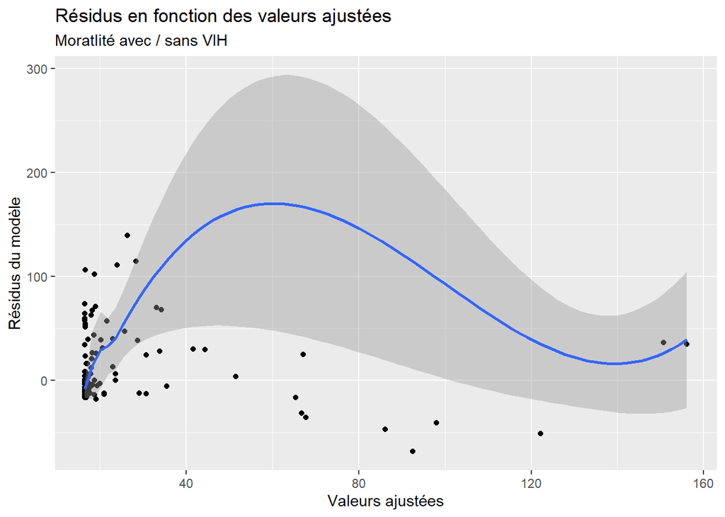

###Analyse :

L’écart-type des résidus semble se réduire pour les valeurs ajustées élevées, ce qui suggère une variabilité moindre des erreurs pour les prédictions élevées.

La courbe lissée indique une forme non linéaire des résidus par rapport aux valeurs ajustées. Cela suggère qu’un modèle linéaire ne s’adapte pas parfaitement aux données, car les erreurs de prédiction ne sont pas distribuées de manière homogène à travers les différentes valeurs ajustées.

Ainsi, le graphique des résidus versus valeurs ajustées montre que la dispersion des résidus varie en fonction des valeurs ajustées. En effet, pour des valeurs ajustées faibles, les résidus sont plus dispersés, tandis que pour des valeurs ajustées élevées, la dispersion des résidus est plus faible. Cela indique que la variance des erreurs n’est pas constante. De plus, la courbe lissée (geom_smooth) montre une forme non linéaire, ce qui signifie que le modèle linéaire ne capture pas toute la dynamique des données. La relation entre les variables semble plus complexe qu’une simple droite.

##qq-plot

`r ggplot() + geom_qq(aes(sample=rstandard(mortality_vs_hiv)))+ geom_abline(color="coral")+ ggtitle("QQ-Plot", subtitle="Motalité avec / sans VIH")`

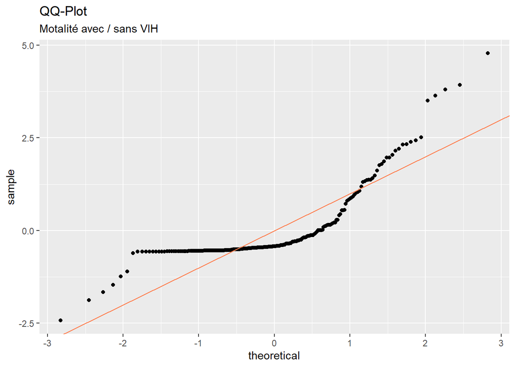

### Analyse

Le QQ-plot montre la distribution des résidus de notre modèle de régression par rapport à une distribution normale théorique.

Analyse du graphique : L’axe théorique représente les quantiles de la distribution normale théorique.

L’axe des échantillons (sample) représente les quantiles des résidus standardisés de votre modèle.

Écarts aux extrémités : Les points commencent à s’éloigner de la droite aux extrémités (dans les valeurs négatives et positives élevées), ce qui suggère que les résidus présentent des queues plus lourdes que ce qui serait attendu d’une distribution normale. Cela pourrait indiquer une asymétrie ou la présence de valeurs extrêmes.

##scale-location (position-échelle)

`r ggplot() + aes(x = fitted(mortality_vs_hiv), y = sqrt(abs(rstandard(mortality_vs_hiv)))) + geom_point() + xlab("Valeurs ajustées") + ylab(expression(sqrt("|Résidus standardisés|"))) + ggtitle("Scale-Location", subtitle="Mortalité avec / sans VIH")`

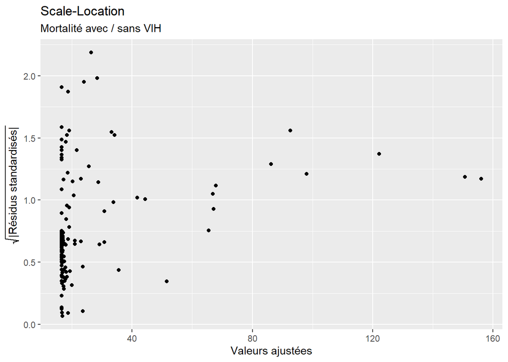

### Analyse

Ce graphique montre la relation entre les valeurs ajustées (prédictions du modèle) et les résidus standardisés (échelles transformées par la racine carrée des résidus absolus). Cela permet d’examiner si l’hypothèse d’homoscédasticité (variance constante des résidus) est respectée.

1. Description du graphique : Axe X : Les valeurs ajustées (c’est-à-dire les prédictions du modèle pour chaque observation).

Axe Y : Les résidus standardisés, transformés par la racine carrée de la valeur absolue des résidus. Cela permet de mieux visualiser la dispersion des résidus.

2. Interprétation du graphique : Les points sont dispersés de manière uniforme sans tendance visible importante, ce qui est un bon signe pour l’homoscédasticité.

Cependant, quelques points se distinguent à gauche (valeurs ajustées faibles), où les résidus standardisés sont plus élevés, ce qui pourrait indiquer une légère variabilité des erreurs pour des petites valeurs ajustées. Cela peut suggérer qu’un modèle linéaire ne s’ajuste pas parfaitement aux données pour ces cas spécifiques.

3. Conclusion : Le graphique montre que, dans l’ensemble, les résidus standardisés sont relativement uniformément dispersés par rapport aux valeurs ajustées, ce qui suggère une homoscédasticité pour la plupart des observations.

Toutefois, quelques points à faible valeur ajustée pourraient indiquer des problèmes locaux (comme une mauvaise spécification du modèle ou des valeurs extrêmes) qu’il faudrait peut-être examiner plus en détail.

En résumé, ce graphique est plutôt positif, mais des points à l’extrémité gauche méritent une attention particulière pour vérifier la stabilité des résidus.

## distance de cook

`r ggplot() + aes(x =seq_along(cooks.distance(mortality_vs_hiv)), y = cooks.distance(mortality_vs_hiv)) + geom_point() + xlab("Numéro d'observation") + ylab("Distance de Cook") + ggtitle("Distance de Cook", subtitle="Mortalité avec / sans VIH")`

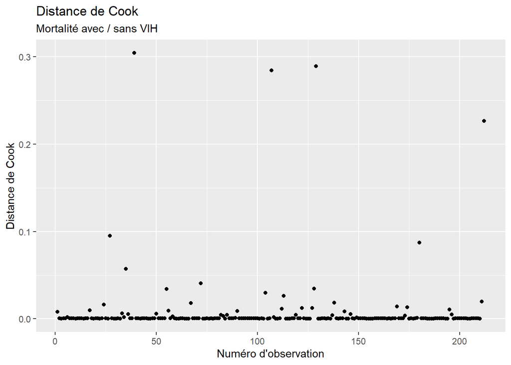

Ce graphique montre la distance de Cook pour chaque observation dans le modèle de régression, ce qui permet d’identifier les observations qui ont une influence excessive sur les coefficients du modèle.

1. Description du graphique : Axe X : Le numéro d’observation, c’est-à-dire l’identifiant de chaque individu dans le jeu de données.

Axe Y : La distance de Cook, qui mesure l’influence de chaque observation sur le modèle. Plus cette distance est grande, plus l’observation a un impact important sur les paramètres du modèle.

2. Interprétation du graphique : La plupart des observations ont une distance de Cook très faible, ce qui indique qu’elles n’ont pas une influence excessive sur le modèle.

3. Conclusion : Le graphique suggère qu’une petite fraction des observations ont une influence significative sur le modèle. Ces points pourraient être des outliers ou des observations particulières qui doivent être vérifiées plus attentivement.

Si ces points influents sont des erreurs de saisie ou des anomalies, leur exclusion ou leur traitement pourrait améliorer l’ajustement du modèle.

En résumé, bien que la plupart des observations n’aient pas une influence majeure, il serait prudent de vérifier les points avec des distances de Cook élevées pour comprendre pourquoi elles ont une telle influence et décider si elles doivent être exclues ou traitées différemment.

##residual versus leverage

`r ggplot() + aes(x =hatvalues(mortality_vs_hiv), y = rstandard(mortality_vs_hiv)) + geom_point(aes(size=cooks.distance(mortality_vs_hiv)),alpha=0.4) + xlab("Levier") + ylab("Résidus standardisés") + ggtitle("Graphique de levier", subtitle="Mortalité avec / sans VIH")`

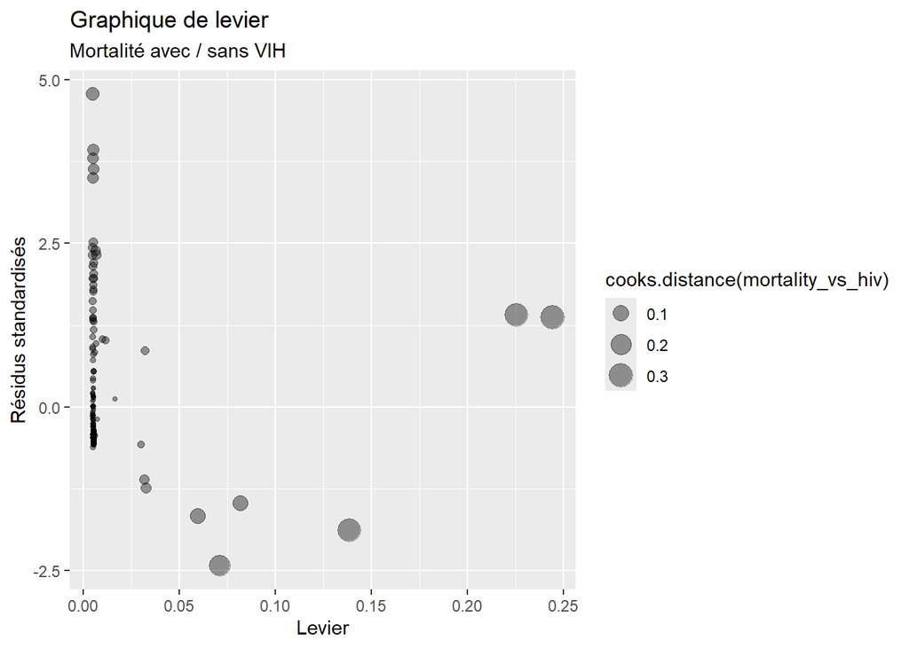

### Analyse :

Ce graphique examine la relation entre les résidus standardisés et le levier des observations dans le modèle de régression, tout en tenant compte de la distance de Cook. Il permet de détecter les points influents, à la fois en termes d’impact sur la régression (résidus) et de leur influence sur le modèle (levier).

1. Description du graphique : Axe X (Levier) : Le levier mesure l’influence potentielle d’une observation sur les valeurs ajustées du modèle. Un levier élevé indique qu’une observation est éloignée de la moyenne des autres observations.

Axe Y (Résidus standardisés) : Les résidus standardisés mesurent l’écart entre les valeurs observées et les valeurs ajustées, normalisées pour tenir compte de la variance des erreurs.

En revanche, la majorité des points se trouvent près de l’axe des résidus (proches de zéro), indiquant que la plupart des observations ont une faible influence sur le modèle.

3. Conclusion : Les points influents (grands cercles) doivent être examinés plus attentivement. Si ces points sont des outliers ou des observations extrêmes, ils pourraient avoir un impact disproportionné sur les résultats du modèle.

Un levier élevé combiné à un résidu important indique qu’une observation a une influence significative sur le modèle, et ces observations doivent être vérifiées pour décider si elles doivent être exclues ou traitées différemment.

En résumé, ce graphique identifie les points influents qui peuvent nécessiter une attention particulière avant d’interpréter pleinement les résultats du modèle.

##II.1.3) prévalence & mortalité avec VIH

##nuage de points

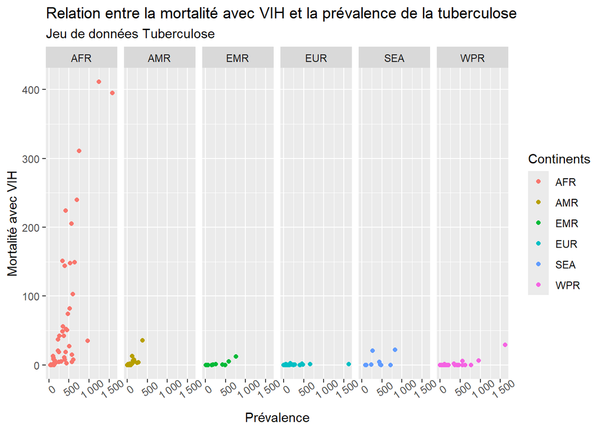

```r
ggplot(TB2_2000)+
  aes(x= `Estimated_prevalence_of_TB_(all_forms)_per_100_000_population`,
      y=`Estimated_mortality_of_TB_cases_who_are_HIV-positive,_per_100_000_population`,
      colour= Region)+
  geom_point()+
  labs(
    x="Prévalence",
    y="Mortalité avec VIH",
    colour="Continents"
  )+
  ggtitle("Relation entre la mortalité avec VIH et la prévalence de la tuberculose",
          subtitle = "Jeu de données Tuberculose")+
  scale_x_continuous(labels = scales::label_number(decimal.mark=","))+
  scale_y_continuous(
    labels = scales::label_number(decimal.mark=",")
  )+
  facet_grid(cols=vars(Region))+
  theme(axis.text.x=element_text(angle=35))
```

### Analyse

Le graphique montre la relation entre la prévalence de la tuberculose (toutes formes) et la mortalité due à la tuberculose chez les personnes vivant avec le VIH pour différents continents.

1. Description du graphique : Axe X (Prévalence) : Il représente la prévalence de la tuberculose par 100 000 habitants, soit le nombre de cas de tuberculose dans la population.

Axe Y (Mortalité avec VIH) : Il représente la mortalité de la tuberculose chez les personnes vivant avec le VIH par 100 000 habitants.

Facettes : Le graphique est divisé en plusieurs facettes, chacune représentant un continent, ce qui permet de comparer la relation entre la prévalence et la mortalité avec VIH dans chaque région.

Variations régionales :

Certaines régions, comme l’Afrique (représentée en rouge), montrent une dispersée importante des points, ce qui suggère une hétérogénéité dans la relation entre la prévalence et la mortalité avec VIH. Cette dispersion pourrait être due à des facteurs comme l’accès aux soins, la gestion de la tuberculose, et la co-infection avec le VIH.

3. Conclusion : Le graphique montre que la prévalence de la tuberculose et la mortalité chez les personnes vivant avec le VIH sont généralement liées, mais la force de cette relation varie selon les continents.

Les différences régionales peuvent être dues à des facteurs sociaux, économiques, des politiques de santé différentes ou des pratiques de diagnostic variées.

Il serait pertinent d’explorer cette relation plus en détail dans chaque région pour mieux comprendre les facteurs influençant la mortalité avec VIH dans le cadre de la tuberculose.

## covariance

```r
TB2_2000 %>% select(`Estimated_prevalence_of_TB_(all_forms)_per_100_000_population`,
`Estimated_mortality_of_TB_cases_who_are_HIV-positive,_per_100_000_population`)%>%cov()
```

```
##                                                                              Estimated_prevalence_of_TB_(all_forms)_per_100_000_population
## Estimated_prevalence_of_TB_(all_forms)_per_100_000_population                                                                     79120.66
## Estimated_mortality_of_TB_cases_who_are_HIV-positive,_per_100_000_population                                                       8441.29
##                                                                              Estimated_mortality_of_TB_cases_who_are_HIV-positive,_per_100_000_population
## Estimated_prevalence_of_TB_(all_forms)_per_100_000_population                                                                                    8441.290
## Estimated_mortality_of_TB_cases_who_are_HIV-positive,_per_100_000_population                                                                     3082.145
```

### Analyse

Covariance de la prévalence avec elle-même : 79120.66 La covariance d’une variable avec elle-même est égale à la variance de cette variable. Cela montre à quel point les valeurs de prévalence varient par rapport à leur moyenne. La valeur élevée de 79120.66 indique une dispersion importante des valeurs de prévalence autour de la moyenne, suggérant que la prévalence varie de manière notable.

Covariance entre la prévalence et la mortalité avec VIH : 8441.29 La covariance positive entre la prévalence de la tuberculose et la mortalité due à la tuberculose chez les personnes vivant avec le VIH montre que lorsque la prévalence de la tuberculose augmente, la mortalité tend également à augmenter (et vice versa). Cette relation positive indique qu’une plus grande prévalence dans une région est généralement associée à une plus grande mortalité chez les personnes vivant avec le VIH.

Covariance de la mortalité avec VIH avec elle-même : 3082.145 La covariance de la mortalité avec VIH avec elle-même représente la variance de cette variable. Elle montre à quel point les valeurs de mortalité varient autour de leur moyenne. La valeur de 3082.145 indique une dispersion modérée des valeurs de mortalité par rapport à la moyenne.

3. Conclusion : La covariance positive entre la prévalence et la mortalité avec VIH (8441.29) confirme qu’il existe une relation directe entre ces deux variables : lorsque la prévalence de la tuberculose augmente, la mortalité avec VIH augmente également.

Cependant, la covariance est influencée par les unités des variables, ce qui rend difficile l’évaluation de la force de la relation. Pour obtenir une mesure normalisée de cette relation, il serait préférable de calculer le coefficient de corrélation entre ces variables, ce qui permettrait de mieux comprendre la force et la direction de la relation entre la prévalence et la mortalité avec VIH.

##coefficient de corrélation pearson

```r
cor(x=TB2_2000[["Estimated_prevalence_of_TB_(all_forms)_per_100_000_population"]], y=TB2_2000[["Estimated_mortality_of_TB_cases_who_are_HIV-positive,_per_100_000_population"]], method ="pearson")
```

```
## [1] 0.5405518
```

##coefficient de corrélation Spearman

```r
cor(x=TB2_2000[["Estimated_prevalence_of_TB_(all_forms)_per_100_000_population"]], y=TB2_2000[["Estimated_mortality_of_TB_cases_who_are_HIV-positive,_per_100_000_population"]], method ="spearman")
```

```
## [1] 0.6459321
```

### Analyse :

Coefficients de corrélation : Coefficient de corrélation de Pearson : 0.5405518 Un coefficient de 0.5405 indique une relation positive modérée et linéaire entre la prévalence et la mortalité de la tuberculose chez les personnes vivant avec le VIH. Cela signifie que, lorsque la prévalence de la tuberculose augmente, la mortalité chez les personnes vivant avec le VIH a tendance à augmenter également, mais de manière modérée et linéaire. La valeur de 0.5405 montre que la relation linéaire entre ces deux variables est modérée, et il existe encore des variations importantes qui ne sont pas expliquées par cette relation.

Coefficient de corrélation de Spearman : 0.6459321 Un coefficient de 0.6459 pour Spearman indique une relation monotone modérée à forte entre la prévalence et la mortalité chez les personnes vivant avec le VIH. Cela signifie que, bien que la relation ne soit pas nécessairement linéaire, les deux variables tendent à évoluer de manière similaire : à mesure que l’une augmente, l’autre augmente aussi. La valeur proche de 0.65 montre que la relation monotone entre ces deux variables est relativement forte, bien qu’il reste des fluctuations importantes.

Conclusion : Le coefficient de Pearson (0.5405) suggère une relation modérée et linéaire entre la prévalence et la mortalité chez les personnes vivant avec le VIH, ce qui indique que l’augmentation de la prévalence est associée à une augmentation modérée de la mortalité.

Le coefficient de Spearman (0.6459) montre une relation monotone modérée à forte, ce qui signifie que bien que cette relation ne soit pas strictement linéaire, les deux variables ont une tendance générale à augmenter ensemble.

Dans les deux cas, la corrélation est modérée mais significative, indiquant une relation entre la prévalence de la tuberculose et la mortalité chez les personnes vivant avec le VIH. Cependant, le coefficient de Spearman montre que la relation est plus robuste en termes de monotonie.

##regression linéaire

```r
mortalite_avec_vih_vs_prevalance<-TB2_2000%>% lm(`Estimated_mortality_of_TB_cases_who_are_HIV-positive,_per_100_000_population` ~
                               `Estimated_prevalence_of_TB_(all_forms)_per_100_000_population`,
                             data =.)

# Résumé du modèle
summary(mortalite_avec_vih_vs_prevalance)
```

```
##
## Call:
## lm(formula = `Estimated_mortality_of_TB_cases_who_are_HIV-positive,_per_100_000_population` ~
##     `Estimated_prevalence_of_TB_(all_forms)_per_100_000_population`,
##     data = .)
##
## Residuals:
##      Min       1Q   Median       3Q      Max
## -165.638  -10.022    1.190    5.056  284.697
##
## Coefficients:
##                                                                 Estimate
## (Intercept)                                                     -6.41809
## `Estimated_prevalence_of_TB_(all_forms)_per_100_000_population`  0.10669
##                                                                 Std. Error
## (Intercept)                                                        4.02503
## `Estimated_prevalence_of_TB_(all_forms)_per_100_000_population`    0.01146
##                                                                 t value
## (Intercept)                                                      -1.595
## `Estimated_prevalence_of_TB_(all_forms)_per_100_000_population`   9.311
##                                                                 Pr(>|t|)
## (Intercept)                                                        0.112
## `Estimated_prevalence_of_TB_(all_forms)_per_100_000_population`   <2e-16 ***
## ---
## Signif. codes:  0 '***' 0.001 '**' 0.01 '*' 0.05 '.' 0.1 ' ' 1
##
## Residual standard error: 46.82 on 210 degrees of freedom
## Multiple R-squared:  0.2922, Adjusted R-squared:  0.2888
## F-statistic: 86.69 on 1 and 210 DF,  p-value: < 2.2e-16
```